# Worldwide Food vs. Feed Production

This is a dataset of worldwide food production. The data compares “food”, which is consumed by humans, with “feed”, which is comnsumed by livestock. https://www.kaggle.com/dorbicycle/world-foodfeed-production

### Research Goal

The goal of this report will be to analyze how food production has changed over time. I am particularly interested in investigating comparing small vs. large countries, and rich vs. poor countries, to see how the food and feed distributions match up. The scales are log10 to normalize for population.

### Small vs. Large Countries

Here I will compare the distribution of food vs. feed for wheat in small countries.

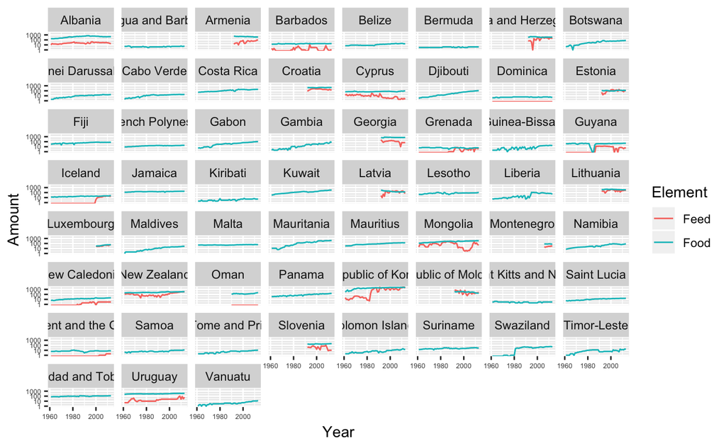

```r
ggplot(countriesbyFood[countriesbyFood$Item=="Wheat and products" & countriesbyFood$pop < 5000000,]) +
  geom_line(aes(x = Year, y=Amount, color=Element)) +
  scale_y_log10() +
  facet_wrap(~Area) +
  theme(axis.text=element_text(size=5))
```

Next is the distribution of food vs. food for wheat in large countries.

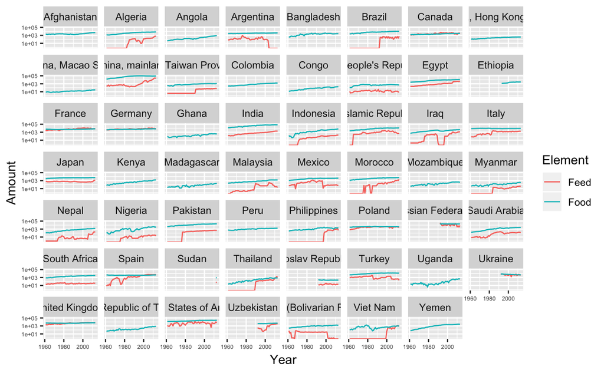

```r
ggplot(countriesbyFood[countriesbyFood$Item=="Wheat and products" & countriesbyFood$pop > 25000000,]) +
  geom_line(aes(x = Year, y=Amount, color=Element)) +
  scale_y_log10() +
  facet_wrap(~Area) +
  theme(axis.text=element_text(size=5))
```

It is clear that large countries produce more feed overall. For both large and small countries, feed production is more variable than food production.

### Rich and Poor Countries

Here is the distribution for rich countries:

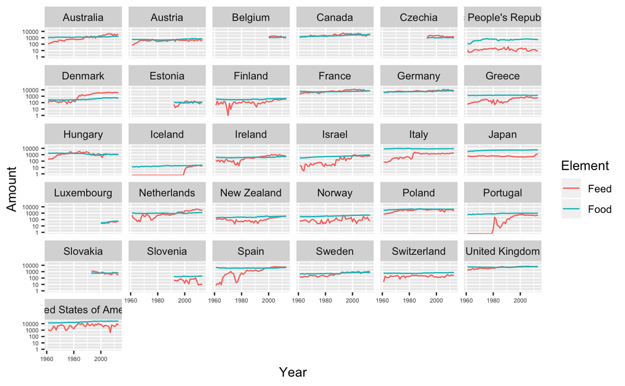

```r
ggplot(countriesbyFood[countriesbyFood$Item=="Wheat and products" & countriesbyFood$INCOME_GRP == 1,]) +
  geom_line(aes(x = Year, y=Amount, color=Element)) +
  scale_y_log10() +
  facet_wrap(~Area) +
  theme(axis.text=element_text(size=5))
```

Here are the poor countries:

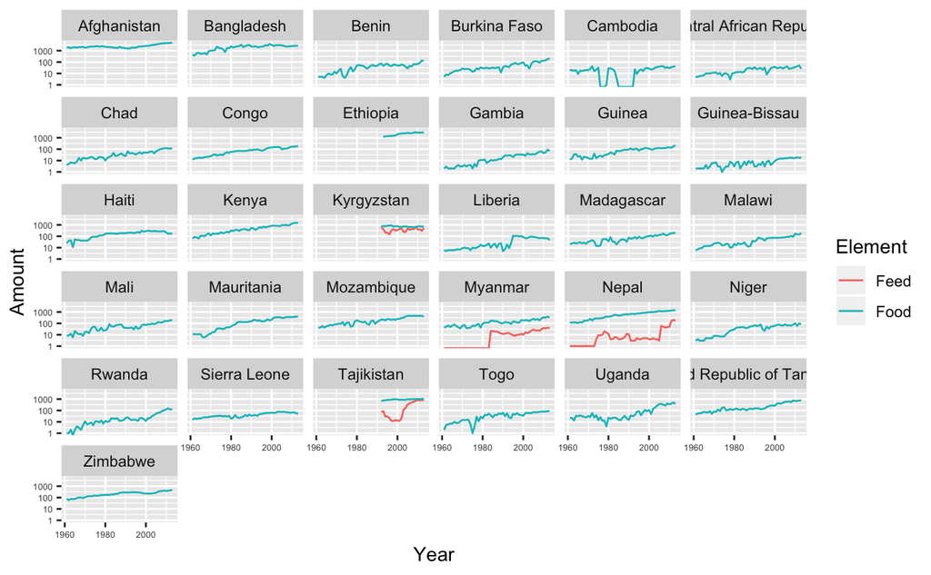

```r
ggplot(countriesbyFood[countriesbyFood$Item=="Wheat and products" & countriesbyFood$INCOME_GRP == 5,]) +
  geom_line(aes(x = Year, y=Amount, color=Element)) +
  scale_y_log10() +
  facet_wrap(~Area) +
  theme(axis.text=element_text(size=5))
```

Similar to the divide between small and large nations, it is evident that rich countries produce feed and food, and poor countries produce only food. However, while rich countries production of food has remained flat over the past 50 years, nearly all poor countries have had a notable increase in production.

### Correlation between feed and food

Now, I will test if there is a correlation between feed, food, and GDP.

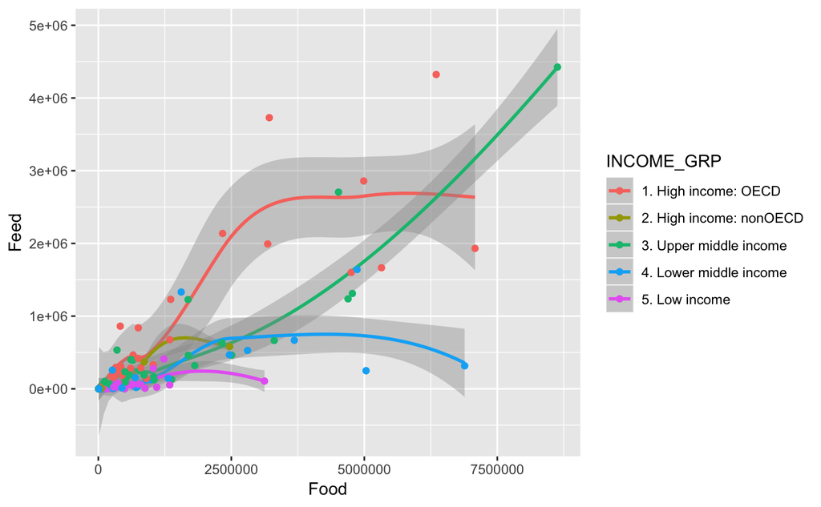

```r
load('countryRatios.rdata')
countryRatios <- countryRatios[countryRatios$Food < 20000000,]##this filters out three outliers
ggplot(countryRatios, aes(x=Food, y=Feed, color=INCOME_GRP)) + geom_point() + geom_smooth() + geom_jitter()
```

There appears to be a positive correlation between food and feed. Rich countries produce more of each than poor countries.

```r
cor.test(countryRatios$Food, countryRatios$Feed)
```

```
    Pearson's product-moment correlation

data:  countryRatios$Food and countryRatios$Feed
t = 16.636, df = 164, p-value < 2.2e-16
alternative hypothesis: true correlation is not equal to 0
95 percent confidence interval:
 0.7279575 0.8429852
sample estimates:
      cor
0.7924133
```

The correlation test shows that there is a statistically significant correlation between food and feed. The correlation coefficient is .79, which suggests a strong positive correlation.

### Correlation between Food and GDP

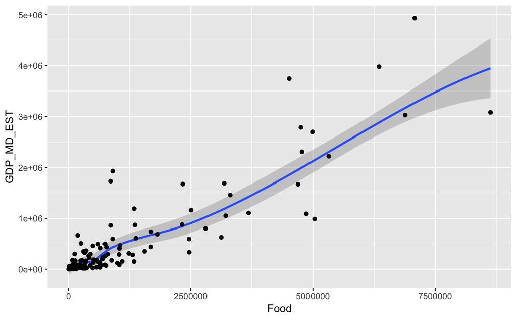

```r
ggplot(countryRatios, aes(x=Food, y=GDP_MD_EST)) + geom_point() + geom_smooth() + geom_jitter()
```

This graph looks eerily similar to the previous food vs. feed example! Now let’s test the correlation.

```r
cor.test(countryRatios$Food, countryRatios$GDP_MD_EST)
```

```
    Pearson's product-moment correlation

data:  countryRatios$Food and countryRatios$GDP_MD_EST
t = 25.077, df = 164, p-value < 2.2e-16
alternative hypothesis: true correlation is not equal to 0
95 percent confidence interval:
 0.8541406 0.9183358
sample estimates:
      cor
0.8905925
```

This time, there is a statistically significant correlation, and an even higher coefficient: 0.89.

### Correlation between Feed and GDP

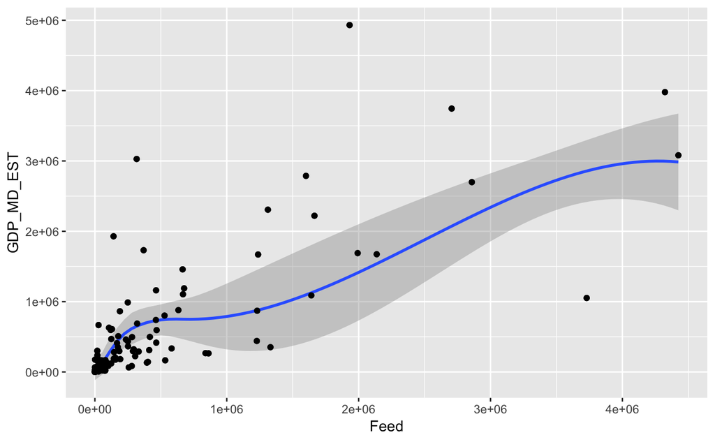

```r
ggplot(countryRatios, aes(x=Feed, y=GDP_MD_EST)) + geom_point() + geom_smooth() + geom_jitter()
```

Again, a positive correlation, but it seems weaker.

```r
cor.test(countryRatios$Feed, countryRatios$GDP_MD_EST)
```

```
    Pearson's product-moment correlation

data:  countryRatios$Feed and countryRatios$GDP_MD_EST
t = 16.248, df = 164, p-value < 2.2e-16
alternative hypothesis: true correlation is not equal to 0
95 percent confidence interval:
 0.7190885 0.8375136
sample estimates:
      cor
0.7853847
```

The correlation between Feed and GDP is less than that of Food and GDP.

### Conclusions

Production of food is strongly correlated with feed. Both food and feed are strongly correlated with GDP.

Rich countries produce a large amount of food, but the variability has remained small over time. Poor countries have been producing an increasingly greater amount of food over the past 50 years.

Food, Feed, and GDP are all highly correlated. Amount of food produced is very highly correlated with GDP.